# Bankchurnneuralnetwork

### Background and Context

Businesses like banks that provide service have to worry about the problem of 'churn'. i.e. customers leaving and joining another service provider. I is important to understand which aspect of the service influence customer's decision in this regard. Management can concentrate efforts on improving the service keeping in mind these priorities.

### Objective :

Given a bank customer, build a neural network based classifier that can determine whether they will leave or not in next 6 months.

### Data Dictionary

- CustomerId: Unique ID which is assigned to each customer
- Surname: Last name of the customer
- CreditScore: It defines the credit history of the customer.
- Geography: A customer’s location
- Gender: It defines the Gender of the customer
- Age: Age of the customer
- Tenure: Number of years for which the customer has been with the bank
- NumOfProducts: It refers to the number of products that a customer has purchased through the bank.
- Balance: Account balance
- HasCrCard: It is a categorical variable that decides whether the customer has a credit card or not.
- EstimatedSalary: Estimated salary
- isActiveMember: It is a categorical variable that decides whether the customer is an active member of the bank or not ( Active member in the sense, using bank products regularly, making transactions, etc )
- Excited: It is a categorical variable that decides whether the customer left the bank within six months or not. It can take two values

0=No ( Customer did not leave the bank )

1=Yes ( Customer left the bank )

### Key Questions:

- What are the key factors influencing the customers to exit the bank ?
- To what extent do each of the variables impact the decision to leave ?
- What is the correlation between these attributes if any?
- Is there a good predictive neural network model for predicting customers who are likely to exit? What does the performance assessment look like for such a model?
- What are the conclusions and takeways from comparison of all the models built
- What is further scope for improvement in the models

### Import all necessary libraries

```python
import warnings
warnings.filterwarnings('ignore')
pd.set_option("display.max_columns", None)
#importing tensorflow
import tensorflow as tf
print(tf.__version__)
```

```
1.14.0
```

```python
from tensorflow.python import keras
```

```python
import pandas as pd
import numpy as np
from sklearn.model_selection import train_test_split
import tensorflow as tf
from sklearn import preprocessing
from tensorflow.keras.models import Sequential
from tensorflow.keras.layers import Dense, Dropout
from tensorflow.keras.optimizers import Adam
from sklearn.metrics import accuracy_score, confusion_matrix, precision_score, recall_score, f1_score, precision_recall_curve, auc, roc_curve,roc_auc_score
import matplotlib.pyplot as plt
from tensorflow.keras import optimizers
from sklearn.decomposition import PCA
import seaborn as sns

import tensorflow as tf
from tensorflow.python import keras
#from keras import backend as K
#from keras.models import Sequential
#from keras.layers import Dense, Dropout
#from keras.optimizers import Adam


from sklearn.model_selection import cross_val_score
from tensorflow.keras.layers import BatchNormalization
from tensorflow.keras.optimizers import Adam, SGD, RMSprop, Adadelta, Adagrad, Adamax, Nadam, Ftrl
from tensorflow.keras.callbacks import EarlyStopping, ModelCheckpoint
from tensorflow.keras.wrappers.scikit_learn import KerasClassifier
from math import floor
from sklearn.metrics import make_scorer, accuracy_score

from bayes_opt import BayesianOptimization
from sklearn.model_selection import StratifiedKFold
from tensorflow.keras.layers import LeakyReLU
LeakyReLU = LeakyReLU(alpha=0.1)
```

### Importing data

```python
# Loading the dataset

data = pd.read_csv("D:\\course\\Bank.CSV")
print(f'There are {data.shape[0]} rows and {data.shape[1]} columns.')  # f-string


np.random.seed(2) # setting the random seed via np.random.seed to get the same random result
data.sample(n=10) # 10 random rows
```

```
There are 10000 rows and 14 columns.
```

|  | RowNumber | CustomerId | Surname | CreditScore | Geography | Gender | Age | Tenure | Balance | NumOfProducts | HasCrCard | IsActiveMember | EstimatedSalary | Exited |
| --- | --- | --- | --- | --- | --- | --- | --- | --- | --- | --- | --- | --- | --- | --- |
| 7878 | 7879 | 15760456 | Eberechukwu | 731 | France | Female | 38 | 10 | 123711.73 | 2 | 1 | 0 | 171340.68 | 1 |
| 3224 | 3225 | 15713463 | Tate | 645 | Germany | Female | 41 | 2 | 138881.04 | 1 | 1 | 0 | 129936.53 | 1 |
| 1919 | 1920 | 15739858 | Otitodilichukwu | 618 | France | Male | 56 | 7 | 0.00 | 1 | 1 | 1 | 142400.27 | 1 |
| 4432 | 4433 | 15751193 | Nnaemeka | 621 | Spain | Male | 33 | 4 | 0.00 | 2 | 1 | 1 | 40299.23 | 0 |
| 4835 | 4836 | 15590623 | Kovalyov | 561 | Spain | Male | 34 | 4 | 85141.79 | 2 | 1 | 1 | 29217.37 | 0 |
| 4895 | 4896 | 15589435 | Davide | 784 | France | Male | 31 | 7 | 0.00 | 2 | 1 | 1 | 143204.41 | 0 |
| 7269 | 7270 | 15675926 | Ardis | 655 | Germany | Male | 34 | 7 | 118028.35 | 1 | 1 | 0 | 51226.32 | 1 |
| 1451 | 1452 | 15684198 | McDonald | 551 | France | Female | 38 | 10 | 0.00 | 2 | 1 | 1 | 216.27 | 0 |
| 1742 | 1743 | 15578603 | Alexeieva | 584 | Germany | Female | 54 | 1 | 77354.37 | 1 | 0 | 0 | 138192.98 | 1 |
| 4628 | 4629 | 15788151 | Moore | 650 | Spain | Male | 32 | 1 | 132187.73 | 2 | 1 | 1 | 178331.36 | 0 |

### Overview of Dataset

```python
data.head()
```

|  | RowNumber | CustomerId | Surname | CreditScore | Geography | Gender | Age | Tenure | Balance | NumOfProducts | HasCrCard | IsActiveMember | EstimatedSalary | Exited |
| --- | --- | --- | --- | --- | --- | --- | --- | --- | --- | --- | --- | --- | --- | --- |
| 0 | 1 | 15634602 | Hargrave | 619 | France | Female | 42 | 2 | 0.00 | 1 | 1 | 1 | 101348.88 | 1 |
| 1 | 2 | 15647311 | Hill | 608 | Spain | Female | 41 | 1 | 83807.86 | 1 | 0 | 1 | 112542.58 | 0 |
| 2 | 3 | 15619304 | Onio | 502 | France | Female | 42 | 8 | 159660.80 | 3 | 1 | 0 | 113931.57 | 1 |
| 3 | 4 | 15701354 | Boni | 699 | France | Female | 39 | 1 | 0.00 | 2 | 0 | 0 | 93826.63 | 0 |
| 4 | 5 | 15737888 | Mitchell | 850 | Spain | Female | 43 | 2 | 125510.82 | 1 | 1 | 1 | 79084.10 | 0 |

### Missing values

```python
data.info()
```

```
<class 'pandas.core.frame.DataFrame'>
RangeIndex: 10000 entries, 0 to 9999
Data columns (total 14 columns):
 #   Column           Non-Null Count  Dtype
---  ------           --------------  -----
 0   RowNumber        10000 non-null  int64
 1   CustomerId       10000 non-null  int64
 2   Surname          10000 non-null  object
 3   CreditScore      10000 non-null  int64
 4   Geography        10000 non-null  object
 5   Gender           10000 non-null  object
 6   Age              10000 non-null  int64
 7   Tenure           10000 non-null  int64
 8   Balance          10000 non-null  float64
 9   NumOfProducts    10000 non-null  int64
 10  HasCrCard        10000 non-null  int64
 11  IsActiveMember   10000 non-null  int64
 12  EstimatedSalary  10000 non-null  float64
 13  Exited           10000 non-null  int64
dtypes: float64(2), int64(9), object(3)
memory usage: 1.1+ MB
```

```python
# Checking for the null value in the dataset
data.isna().sum()
```

```
RowNumber          0
CustomerId         0
Surname            0
CreditScore        0
Geography          0
Gender             0
Age                0
Tenure             0
Balance            0
NumOfProducts      0
HasCrCard          0
IsActiveMember     0
EstimatedSalary    0
Exited             0
dtype: int64
```

```python
# let's check for duplicate values in the data
data.duplicated().sum()
```

```
0
```

- There are no duplicates in the data.

```python
# Unique values
data.nunique()
```

```
RowNumber          10000
CustomerId         10000
Surname             2932
CreditScore          460
Geography              3
Gender                 2
Age                   70
Tenure                11
Balance             6382
NumOfProducts          4
HasCrCard              2
IsActiveMember         2
EstimatedSalary     9999
Exited                 2
dtype: int64
```

```python
data.describe()
```

|  | RowNumber | CustomerId | CreditScore | Age | Tenure | Balance | NumOfProducts | HasCrCard | IsActiveMember | EstimatedSalary | Exited |
| --- | --- | --- | --- | --- | --- | --- | --- | --- | --- | --- | --- |
| count | 10000.00000 | 1.000000e+04 | 10000.000000 | 10000.000000 | 10000.000000 | 10000.000000 | 10000.000000 | 10000.00000 | 10000.000000 | 10000.000000 | 10000.000000 |
| mean | 5000.50000 | 1.569094e+07 | 650.528800 | 38.921800 | 5.012800 | 76485.889288 | 1.530200 | 0.70550 | 0.515100 | 100090.239881 | 0.203700 |
| std | 2886.89568 | 7.193619e+04 | 96.653299 | 10.487806 | 2.892174 | 62397.405202 | 0.581654 | 0.45584 | 0.499797 | 57510.492818 | 0.402769 |
| min | 1.00000 | 1.556570e+07 | 350.000000 | 18.000000 | 0.000000 | 0.000000 | 1.000000 | 0.00000 | 0.000000 | 11.580000 | 0.000000 |
| 25% | 2500.75000 | 1.562853e+07 | 584.000000 | 32.000000 | 3.000000 | 0.000000 | 1.000000 | 0.00000 | 0.000000 | 51002.110000 | 0.000000 |
| 50% | 5000.50000 | 1.569074e+07 | 652.000000 | 37.000000 | 5.000000 | 97198.540000 | 1.000000 | 1.00000 | 1.000000 | 100193.915000 | 0.000000 |
| 75% | 7500.25000 | 1.575323e+07 | 718.000000 | 44.000000 | 7.000000 | 127644.240000 | 2.000000 | 1.00000 | 1.000000 | 149388.247500 | 0.000000 |
| max | 10000.00000 | 1.581569e+07 | 850.000000 | 92.000000 | 10.000000 | 250898.090000 | 4.000000 | 1.00000 | 1.000000 | 199992.480000 | 1.000000 |

```python
#Number of distinct categories or classes i.e., Fraudulent and Genuine
data['Exited'].nunique()
```

```
2
```

- As expected, there are only 2 classes.

```python
#checking the percentage of each class in the dataset
(data.Exited.value_counts())/(data.Exited.count())
```

```
0    0.7963
1    0.2037
Name: Exited, dtype: float64
```

- This shows a complete imbalance of classes. There are 79.63% 'Not exiting' (0) instances and only 20.37 'Exiting' (1) instances.

## Univariate analysis

```python
# function to plot a boxplot and a histogram along the same scale.


def histogram_boxplot(data, feature, figsize=(12, 7), kde=False, bins=None):
    """
    Boxplot and histogram combined

    data: dataframe
    feature: dataframe column
    figsize: size of figure (default (12,7))
    kde: whether to the show density curve (default False)
    bins: number of bins for histogram (default None)
    """
    f2, (ax_box2, ax_hist2) = plt.subplots(
        nrows=2,  # Number of rows of the subplot grid= 2
        sharex=True,  # x-axis will be shared among all subplots
        gridspec_kw={"height_ratios": (0.25, 0.75)},
        figsize=figsize,
    )  # creating the 2 subplots
    sns.boxplot(
        data=data, x=feature, ax=ax_box2, showmeans=True, color="violet"
    )  # boxplot will be created and a star will indicate the mean value of the column
    sns.histplot(
        data=data, x=feature, kde=kde, ax=ax_hist2, bins=bins, palette="winter"
    ) if bins else sns.histplot(
        data=data, x=feature, kde=kde, ax=ax_hist2
    )  # For histogram
    ax_hist2.axvline(
        data[feature].mean(), color="green", linestyle="--"
    )  # Add mean to the histogram
    ax_hist2.axvline(
        data[feature].median(), color="black", linestyle="-"
    )  # Add median to the histogram
```

### Observation on Credit Score

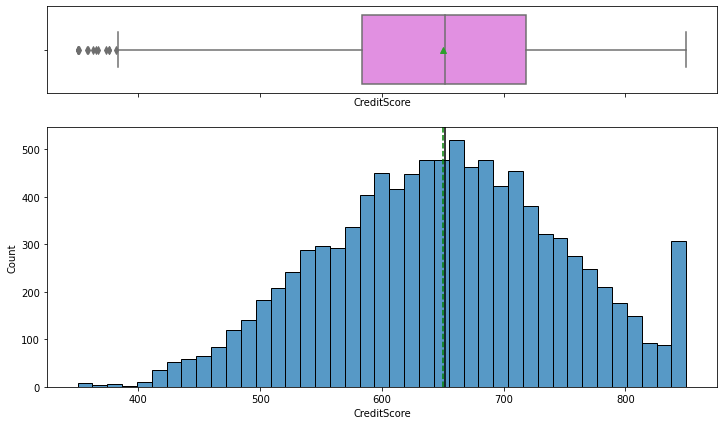

```python
# Observations on CreditScore
histogram_boxplot(data, "CreditScore")
```

- It is fairly evenly distributed

### Observation on Age

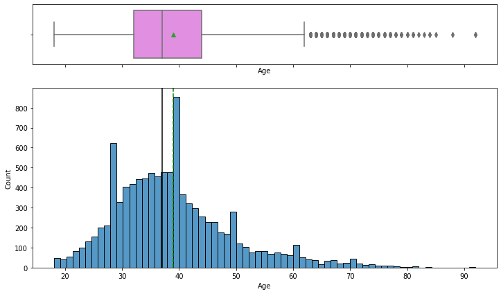

```python
# Observations on Age
histogram_boxplot(data, "Age")
```

- Data is slighlty right skewed
- Presence of outliers

### Observation on Tenure

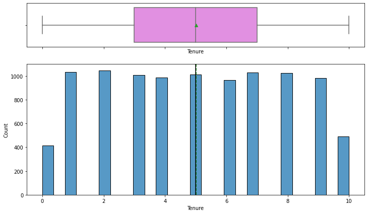

```python
# Observations on Tenure
histogram_boxplot(data, "Tenure")
```

- Data is fairly balanced

### Observation on Balance

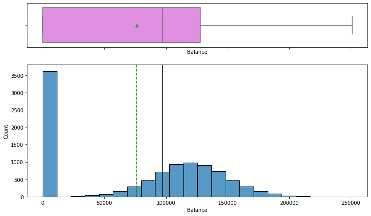

```python
# Observations on Balance
histogram_boxplot(data, "Balance")
```

### Observation on NumOfProducts

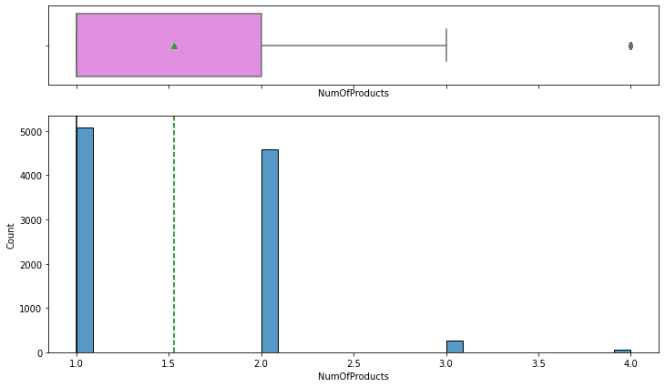

```python
# Observations on NumOfProducts
histogram_boxplot(data, "NumOfProducts")
```

- Data is a bit right skewed with one outlier

### Observation on EstimatedSalary

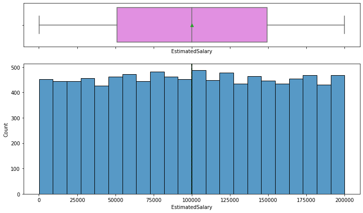

```python
# Observations on EstimatedSalary
histogram_boxplot(data, "EstimatedSalary")
```

- Data is balanced

```python
# function to create labeled barplots


def labeled_barplot(data, feature, perc=False, n=None):
    """
    Barplot with percentage at the top

    data: dataframe
    feature: dataframe column
    perc: whether to display percentages instead of count (default is False)
    n: displays the top n category levels (default is None, i.e., display all levels)
    """

    total = len(data[feature])  # length of the column
    count = data[feature].nunique()
    if n is None:
        plt.figure(figsize=(count + 1, 5))
    else:
        plt.figure(figsize=(n + 1, 5))

    plt.xticks(rotation=90, fontsize=15)
    ax = sns.countplot(
        data=data,
        x=feature,
        palette="Paired",
        order=data[feature].value_counts().index[:n].sort_values(),
    )

    for p in ax.patches:
        if perc == True:
            label = "{:.1f}%".format(
                100 * p.get_height() / total
            )  # percentage of each class of the category
        else:
            label = p.get_height()  # count of each level of the category

        x = p.get_x() + p.get_width() / 2  # width of the plot
        y = p.get_height()  # height of the plot

        ax.annotate(
            label,
            (x, y),
            ha="center",
            va="center",
            size=12,
            xytext=(0, 5),
            textcoords="offset points",
        )  # annotate the percentage

    plt.show()  # show the plot
```

### Observations on Exited

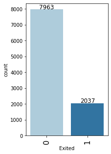

```python
# observations on Attrition flag
labeled_barplot(data, "Exited")
```

- As mentioned earlier, the class distribution in the target variable is imbalanced.
- We have 79% observations for non-churners and 20% observations for bank churners.

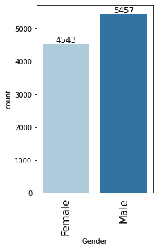

```python
# observations on Gender
labeled_barplot(data, "Gender")
```

- 54% are males
- 45% females

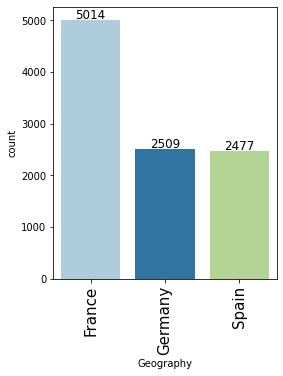

```python
# observations on Geography
labeled_barplot(data, "Geography")
```

- 50% data for french customers
- german and spanish customers evenly distributed approx at 25%

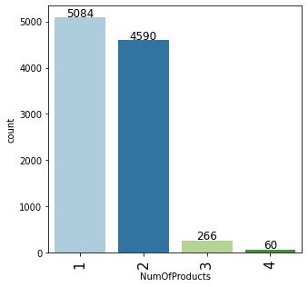

```python
# observations on NumOfProducts
labeled_barplot(data, "NumOfProducts")
```

- 50% products are for product 1
- next 45% are for product 2
- product 3 and 4 constitue 5%

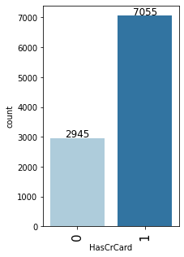

```python
# observations on HasCrCard
labeled_barplot(data, "HasCrCard")
```

- 70% have card
- 29% do not have card

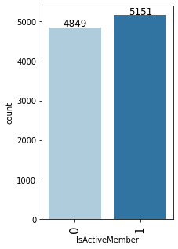

```python
# observations on IsActiveMember
labeled_barplot(data, "IsActiveMember")
```

- 51% are active members
- 48% are not active members

## Bivariate Analysis

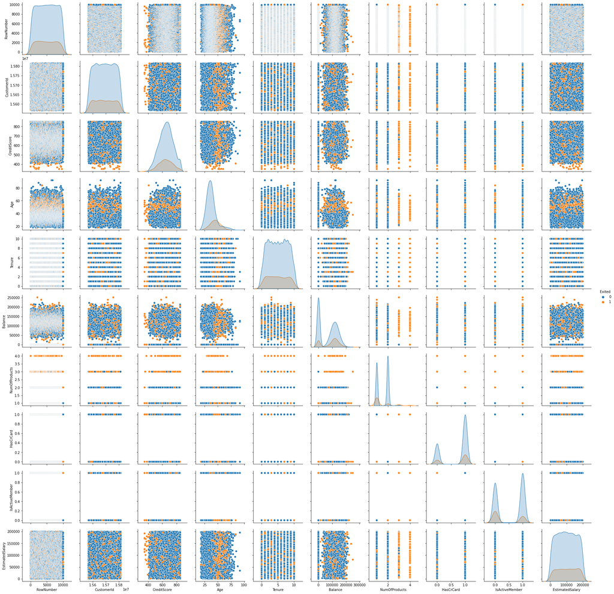

```python
sns.pairplot(data, hue="Exited")
```

- There are overlaps i.e. no clear distinction in the distribution of variables for people who have exited and did not exit.

### Impact of CreditScore on Exited

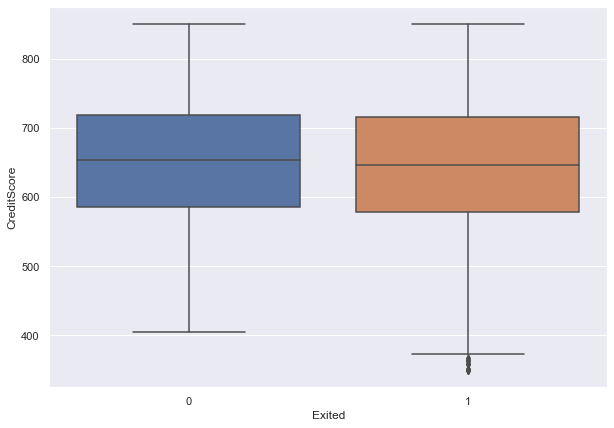

```python
sns.set(rc={"figure.figsize": (10, 7)})
sns.boxplot(x="Exited", y="CreditScore", data=data, orient="vertical")
```

- People exiting have a bit lower credit score

### Impact of Age on Exited

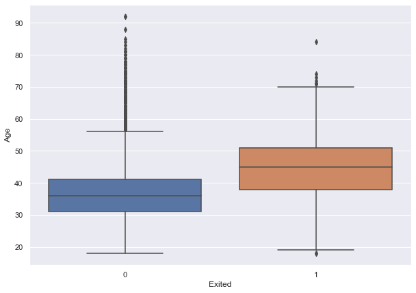

```python
sns.set(rc={"figure.figsize": (10, 7)})
sns.boxplot(x="Exited", y="Age", data=data, orient="vertical")
```

- Older People are exiting. More people above 35 are exiting
- There are more outliers in age for people staying with the bank.

### Impact of Teunre on Exited

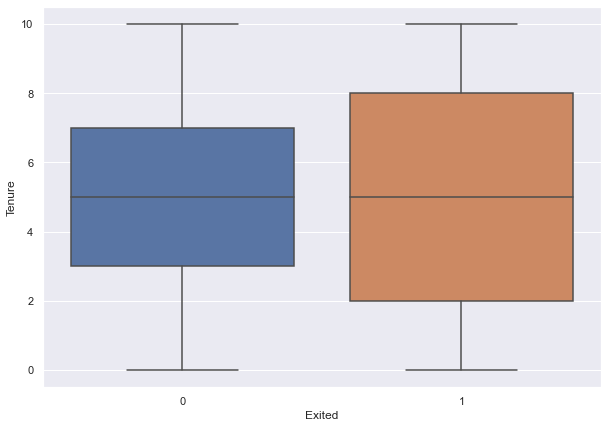

```python
sns.set(rc={"figure.figsize": (10, 7)})
sns.boxplot(x="Exited", y="Tenure", data=data, orient="vertical")
```

- People exiting have a broader range in tenure.

### Impact of Balance on Exited

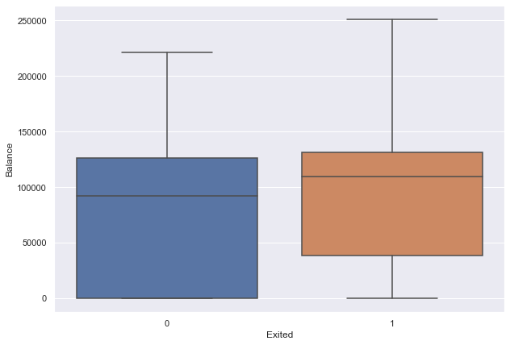

```python
sns.set(rc={"figure.figsize": (10, 7)})
sns.boxplot(x="Exited", y="Balance", data=data, orient="vertical")
```

- People retained with the bank have a brader range of bakance

### Impact of NumOfProducts on Exited

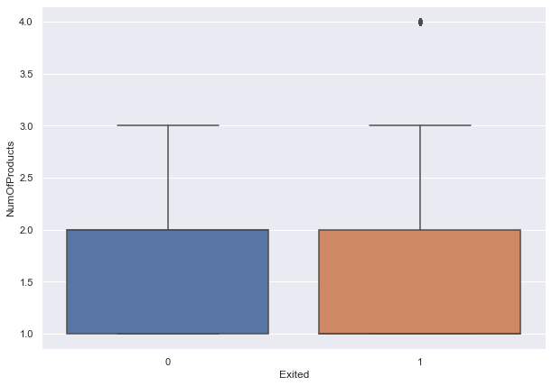

```python
sns.set(rc={"figure.figsize": (10, 7)})
sns.boxplot(x="Exited", y="NumOfProducts", data=data, orient="vertical")
```

### Impact of EstimatedSalary on Exited

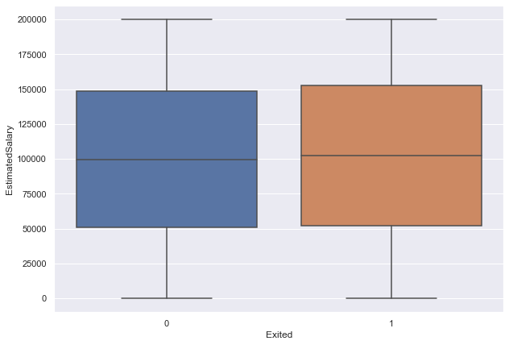

```python
sns.set(rc={"figure.figsize": (10, 7)})
sns.boxplot(x="Exited", y="EstimatedSalary", data=data, orient="vertical")
```

- Estimated salary has similar impact on exiting and retained customers

### Impact of HasCrCard on Exited

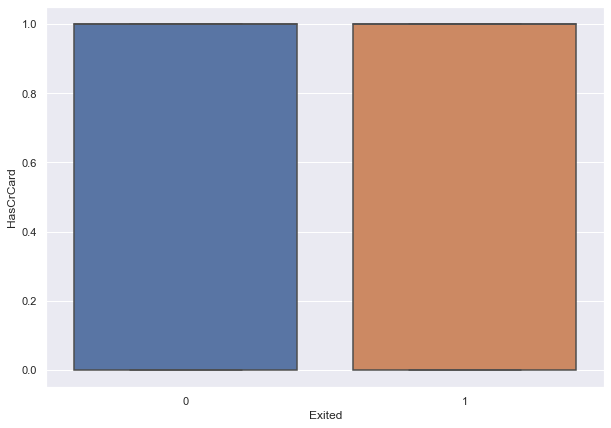

```python
sns.set(rc={"figure.figsize": (10, 7)})
sns.boxplot(x="Exited", y="HasCrCard", data=data, orient="vertical")
```

- same impact for people with credit card and without on exited status

### Impact of IsActiveMember on Exited

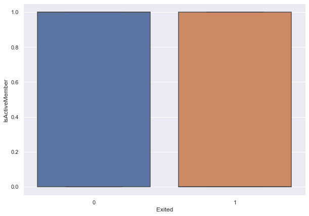

```python
sns.set(rc={"figure.figsize": (10, 7)})
sns.boxplot(x="Exited", y="IsActiveMember", data=data, orient="vertical")
```

```python
# function to plot stacked bar chart


def stacked_barplot(data, predictor, target):
    """
    Print the category counts and plot a stacked bar chart

    data: dataframe
    predictor: independent variable
    target: target variable
    """
    count = data[predictor].nunique()
    sorter = data[target].value_counts().index[-1]
    tab1 = pd.crosstab(data[predictor], data[target], margins=True).sort_values(
        by=sorter, ascending=False
    )
    print(tab1)
    print("-" * 120)
    tab = pd.crosstab(data[predictor], data[target], normalize="index").sort_values(
        by=sorter, ascending=False
    )
    tab.plot(kind="bar", stacked=True, figsize=(count + 1, 5))
    plt.legend(
        loc="lower left",
        frameon=False,
    )
    plt.legend(loc="upper left", bbox_to_anchor=(1, 1))
    plt.show()
```

```
Exited     0     1    All
Gender
All     7963  2037  10000
Female  3404  1139   4543
Male    4559   898   5457
------------------------------------------------------------------------------------------------------------------------
```

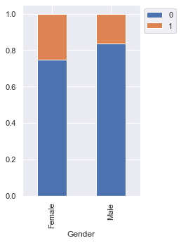

```python
stacked_barplot(data, "Gender", "Exited")
```

- More females exiting

```
Exited        0     1    All
Geography
All        7963  2037  10000
Germany    1695   814   2509
France     4204   810   5014
Spain      2064   413   2477
------------------------------------------------------------------------------------------------------------------------
```

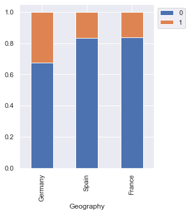

```python
stacked_barplot(data, "Geography", "Exited")
```

```
Exited            0     1    All
NumOfProducts
All            7963  2037  10000
1              3675  1409   5084
2              4242   348   4590
3                46   220    266
4                 0    60     60
------------------------------------------------------------------------------------------------------------------------
```

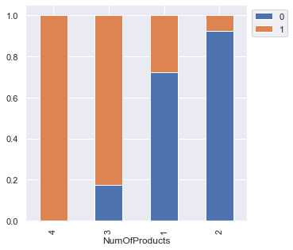

```python
 stacked_barplot(data, "NumOfProducts", "Exited")
```

- Product 4 customers have all exited
- Product 3 customers also have majority exited.
- Product 2 customers have retained more than any other product

```
Exited        0     1    All
HasCrCard
All        7963  2037  10000
1          5631  1424   7055
0          2332   613   2945
------------------------------------------------------------------------------------------------------------------------
```

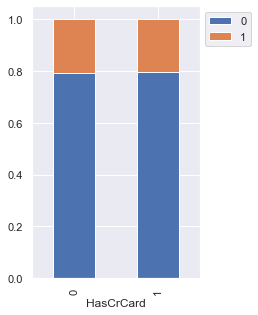

```python
 stacked_barplot(data, "HasCrCard", "Exited")
```

- same impact on people with card or without card on exited status

```
Exited             0     1    All
IsActiveMember
All             7963  2037  10000
0               3547  1302   4849
1               4416   735   5151
------------------------------------------------------------------------------------------------------------------------
```

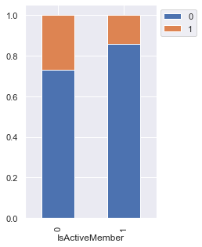

```python
 stacked_barplot(data, "IsActiveMember", "Exited")
```

- More customers who are not active members have exited

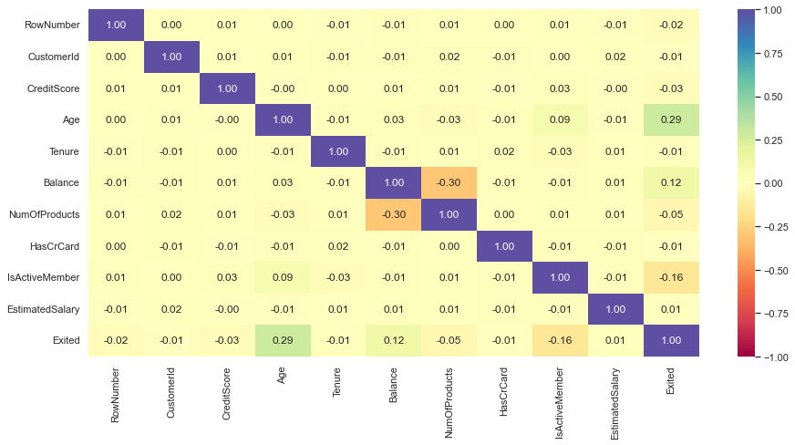

```python
plt.figure(figsize=(15, 7))
sns.heatmap(data.corr(), annot=True, vmin=-1, vmax=1, fmt=".2f", cmap="Spectral")
plt.show()
```

- Overall there is relatively less correlation between the independent variables.
- Maximum positive correlation exists between Age and Exited.
- Some Negative correlation exists between Is active member and Exited.
- Slight positive correlation exists between Balance and Exited.

### Detecting Outliers

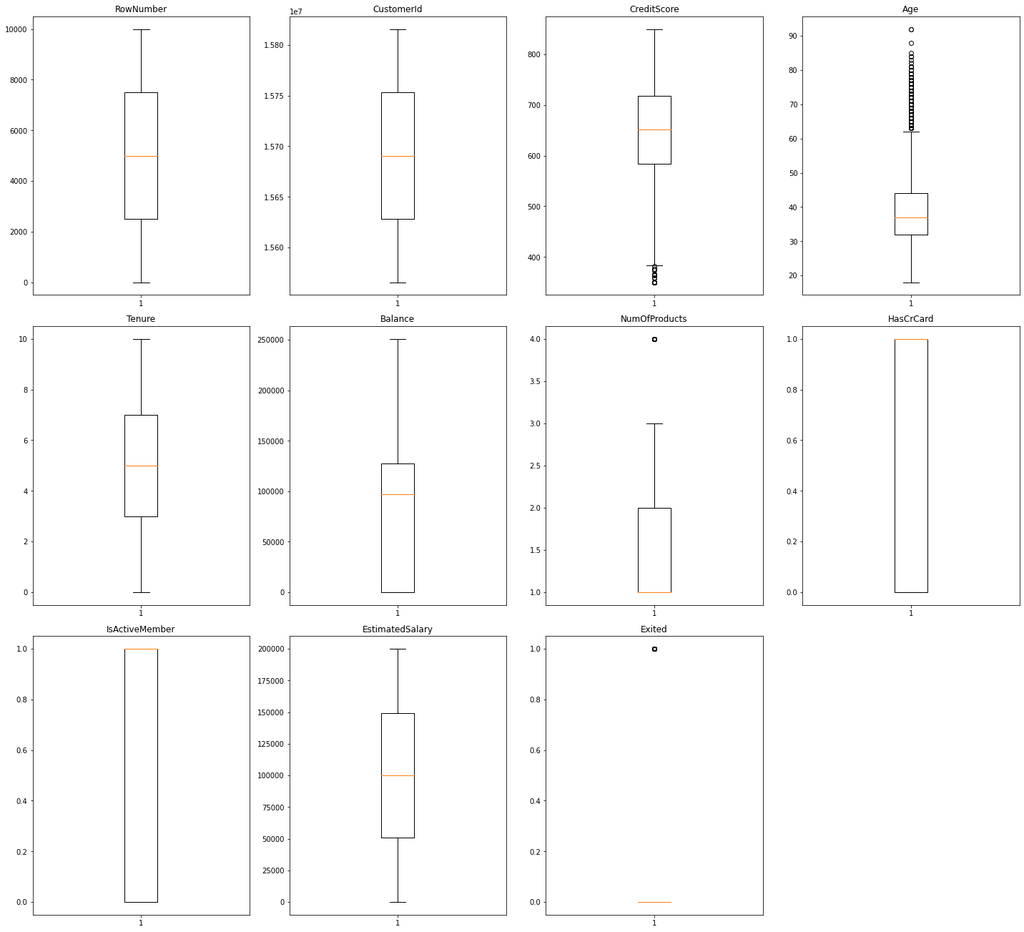

```python
# outlier detection using boxplot
numerical_col = data.select_dtypes(include=np.number).columns.tolist()
plt.figure(figsize=(20,30))

for i, variable in enumerate(numerical_col):
                     plt.subplot(5,4,i+1)
                     plt.boxplot(data[variable],whis=1.5)
                     plt.tight_layout()
                     plt.title(variable)

plt.show()
```

- Treating outliers as they have a potential to skew the models
- There are quite a bit of outliers in the data so it will be good idea to treat them by updating the values smaller than lower whisker to the lower whisker value and updating the values greater than upper whisker to the upper whisker value
- Age , credit score, number of products have outliers which need to be treated.

#### Function to update smaller value to lower whisker and higher value to upper whisker

```python
def treat_outliers(data,col):
    '''
    treats outliers in a varaible
    col: str, name of the numerical varaible
    data: data frame
    col: name of the column
    '''
    Q1=data[col].quantile(0.25) # 25th quantile
    Q3=data[col].quantile(0.75)  # 75th quantile
    IQR=Q3-Q1
    Lower_Whisker = Q1 - 1.5*IQR
    Upper_Whisker = Q3 + 1.5*IQR
    data[col] = np.clip(data[col], Lower_Whisker, Upper_Whisker) # all the values smaller than Lower_Whisker will be assigned value of Lower_whisker
                                                            # and all the values above upper_whisker will be assigned value of upper_Whisker
    return data

def treat_outliers_all(data, col_list):
    '''
    treat outlier in all numerical varaibles
    col_list: list of numerical varaibles
    data: data frame
    '''
    for c in col_list:
        data = treat_outliers(data,c)

    return data
```

```python
numerical_col = data.select_dtypes(include=np.number).columns.tolist()# getting list of numerical columns


# items to be treated
treating= {'CreditScore', 'Age','NumofProducts'}

numerical_col = [ele for ele in numerical_col if ele  in treating]
data = treat_outliers_all(data,numerical_col)
```

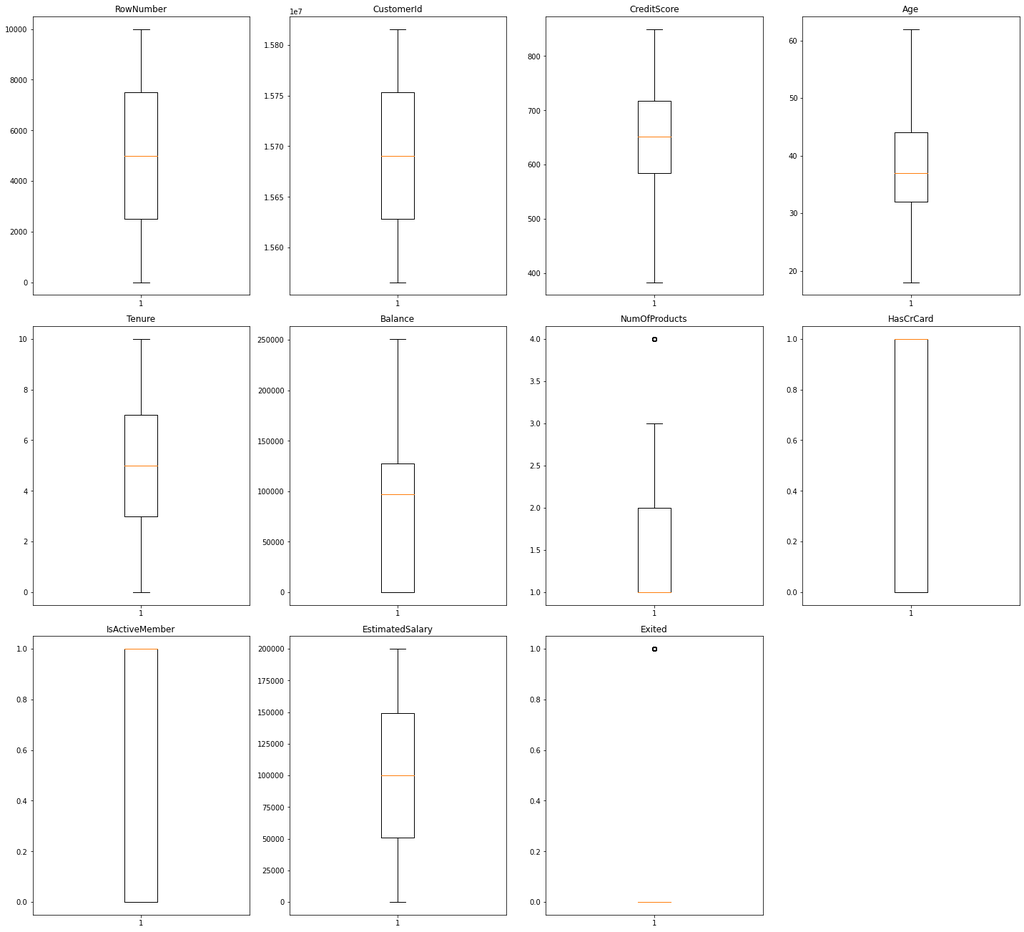

```python
# outlier detection using boxplot
numerical_col = data.select_dtypes(include=np.number).columns.tolist()
plt.figure(figsize=(20,30))

for i, variable in enumerate(numerical_col):
                     plt.subplot(5,4,i+1)
                     plt.boxplot(data[variable],whis=1.5)
                     plt.tight_layout()
                     plt.title(variable)

plt.show()
```

```python
data.info()
```

```
<class 'pandas.core.frame.DataFrame'>
RangeIndex: 10000 entries, 0 to 9999
Data columns (total 14 columns):
 #   Column           Non-Null Count  Dtype
---  ------           --------------  -----
 0   RowNumber        10000 non-null  int64
 1   CustomerId       10000 non-null  int64
 2   Surname          10000 non-null  object
 3   CreditScore      10000 non-null  int64
 4   Geography        10000 non-null  object
 5   Gender           10000 non-null  object
 6   Age              10000 non-null  int64
 7   Tenure           10000 non-null  int64
 8   Balance          10000 non-null  float64
 9   NumOfProducts    10000 non-null  int64
 10  HasCrCard        10000 non-null  int64
 11  IsActiveMember   10000 non-null  int64
 12  EstimatedSalary  10000 non-null  float64
 13  Exited           10000 non-null  int64
dtypes: float64(2), int64(9), object(3)
memory usage: 1.1+ MB
```

- Dropping Customer Id, surname columns since they are not playing any role

```python
df = data.drop("CustomerId", axis=1)
```

```python
df1 = df.drop("Surname", axis=1)
```

```python
df1.info()
```

```
<class 'pandas.core.frame.DataFrame'>
RangeIndex: 10000 entries, 0 to 9999
Data columns (total 12 columns):
 #   Column           Non-Null Count  Dtype
---  ------           --------------  -----
 0   RowNumber        10000 non-null  int64
 1   CreditScore      10000 non-null  int64
 2   Geography        10000 non-null  object
 3   Gender           10000 non-null  object
 4   Age              10000 non-null  int64
 5   Tenure           10000 non-null  int64
 6   Balance          10000 non-null  float64
 7   NumOfProducts    10000 non-null  int64
 8   HasCrCard        10000 non-null  int64
 9   IsActiveMember   10000 non-null  int64
 10  EstimatedSalary  10000 non-null  float64
 11  Exited           10000 non-null  int64
dtypes: float64(2), int64(8), object(2)
memory usage: 937.6+ KB
```

```python
df2 = df1.drop("RowNumber", axis=1)
```

```python
df2.info()
```

```
<class 'pandas.core.frame.DataFrame'>
RangeIndex: 10000 entries, 0 to 9999
Data columns (total 11 columns):
 #   Column           Non-Null Count  Dtype
---  ------           --------------  -----
 0   CreditScore      10000 non-null  int64
 1   Geography        10000 non-null  object
 2   Gender           10000 non-null  object
 3   Age              10000 non-null  int64
 4   Tenure           10000 non-null  int64
 5   Balance          10000 non-null  float64
 6   NumOfProducts    10000 non-null  int64
 7   HasCrCard        10000 non-null  int64
 8   IsActiveMember   10000 non-null  int64
 9   EstimatedSalary  10000 non-null  float64
 10  Exited           10000 non-null  int64
dtypes: float64(2), int64(7), object(2)
memory usage: 859.5+ KB
```

#### Separating target variable and independent variables

```python
X = df2.drop("Exited", axis=1)
Y = df2["Exited"]
```

```python
X.head()
```

|  | CreditScore | Geography | Gender | Age | Tenure | Balance | NumOfProducts | HasCrCard | IsActiveMember | EstimatedSalary |
| --- | --- | --- | --- | --- | --- | --- | --- | --- | --- | --- |
| 0 | 619 | France | Female | 42 | 2 | 0.00 | 1 | 1 | 1 | 101348.88 |
| 1 | 608 | Spain | Female | 41 | 1 | 83807.86 | 1 | 0 | 1 | 112542.58 |
| 2 | 502 | France | Female | 42 | 8 | 159660.80 | 3 | 1 | 0 | 113931.57 |
| 3 | 699 | France | Female | 39 | 1 | 0.00 | 2 | 0 | 0 | 93826.63 |
| 4 | 850 | Spain | Female | 43 | 2 | 125510.82 | 1 | 1 | 1 | 79084.10 |

### Data Pre-processing

#### Applying standard scaler

```python
#Standardizing the CreditScore column
from sklearn.preprocessing import StandardScaler
X['normalizedCreditScore'] = StandardScaler().fit_transform(X['CreditScore'].values.reshape(-1,1))  # Normalize 'Amount' in [-1,+1] range
X= X.drop(['CreditScore'],axis=1)
```

```python
#Standardizing the Balance column
from sklearn.preprocessing import StandardScaler
X['normalizedBalance'] = StandardScaler().fit_transform(X['Balance'].values.reshape(-1,1))  # Normalize 'Amount' in [-1,+1] range
X= X.drop(['Balance'],axis=1)
```

```python
#Standardizing the EstimatedSalary column
from sklearn.preprocessing import StandardScaler
X['normalizedEstimatedSalary'] = StandardScaler().fit_transform(X['EstimatedSalary'].values.reshape(-1,1))  # Normalize 'Amount' in [-1,+1] range
X= X.drop(['EstimatedSalary'],axis=1)
```

```python
#Standardizing the Age column
from sklearn.preprocessing import StandardScaler
X['normalizedAge'] = StandardScaler().fit_transform(X['Age'].values.reshape(-1,1))  # Normalize 'Amount' in [-1,+1] range
X= X.drop(['Age'],axis=1)
```

```python
#Standardizing the Tenure column
from sklearn.preprocessing import StandardScaler
X['normalizedTenure'] = StandardScaler().fit_transform(X['Tenure'].values.reshape(-1,1))  # Normalize 'Amount' in [-1,+1] range
X= X.drop(['Tenure'],axis=1)
```

```python
#Standardizing the NumOfProducts column
from sklearn.preprocessing import StandardScaler
X['normalizedNumOfProducts'] = StandardScaler().fit_transform(X['NumOfProducts'].values.reshape(-1,1))  # Normalize 'Amount' in [-1,+1] range
X= X.drop(['NumOfProducts'],axis=1)
```

```python
X.head()
```

|  | Geography | Gender | HasCrCard | IsActiveMember | normalizedCreditScore | normalizedBalance | normalizedEstimatedSalary | normalizedAge | normalizedTenure | normalizedNumOfProducts |
| --- | --- | --- | --- | --- | --- | --- | --- | --- | --- | --- |
| 0 | France | Female | 1 | 1 | -0.326878 | -1.225848 | 0.021886 | 0.342615 | -1.041760 | -0.911583 |
| 1 | Spain | Female | 0 | 1 | -0.440804 | 0.117350 | 0.216534 | 0.240011 | -1.387538 | -0.911583 |
| 2 | France | Female | 1 | 0 | -1.538636 | 1.333053 | 0.240687 | 0.342615 | 1.032908 | 2.527057 |
| 3 | France | Female | 0 | 0 | 0.501675 | -1.225848 | -0.108918 | 0.034803 | -1.387538 | 0.807737 |
| 4 | Spain | Female | 1 | 1 | 2.065569 | 0.785728 | -0.365276 | 0.445219 | -1.041760 | -0.911583 |

- Converting categorical to numerical by dummy value substitution.

```python
X = pd.get_dummies(data=X, drop_first=True)
```

```python
X.info()
```

```
<class 'pandas.core.frame.DataFrame'>
RangeIndex: 10000 entries, 0 to 9999
Data columns (total 11 columns):
 #   Column                     Non-Null Count  Dtype
---  ------                     --------------  -----
 0   HasCrCard                  10000 non-null  int64
 1   IsActiveMember             10000 non-null  int64
 2   normalizedCreditScore      10000 non-null  float64
 3   normalizedBalance          10000 non-null  float64
 4   normalizedEstimatedSalary  10000 non-null  float64
 5   normalizedAge              10000 non-null  float64
 6   normalizedTenure           10000 non-null  float64
 7   normalizedNumOfProducts    10000 non-null  float64
 8   Geography_Germany          10000 non-null  uint8
 9   Geography_Spain            10000 non-null  uint8
 10  Gender_Male                10000 non-null  uint8
dtypes: float64(6), int64(2), uint8(3)
memory usage: 654.4 KB
```

#### Splitting Data into training and testing

```python
X.head()
```

|  | HasCrCard | IsActiveMember | normalizedCreditScore | normalizedBalance | normalizedEstimatedSalary | normalizedAge | normalizedTenure | normalizedNumOfProducts | Geography_Germany | Geography_Spain | Gender_Male |
| --- | --- | --- | --- | --- | --- | --- | --- | --- | --- | --- | --- |
| 0 | 1 | 1 | -0.326878 | -1.225848 | 0.021886 | 0.342615 | -1.041760 | -0.911583 | 0 | 0 | 0 |
| 1 | 0 | 1 | -0.440804 | 0.117350 | 0.216534 | 0.240011 | -1.387538 | -0.911583 | 0 | 1 | 0 |
| 2 | 1 | 0 | -1.538636 | 1.333053 | 0.240687 | 0.342615 | 1.032908 | 2.527057 | 0 | 0 | 0 |
| 3 | 0 | 0 | 0.501675 | -1.225848 | -0.108918 | 0.034803 | -1.387538 | 0.807737 | 0 | 0 | 0 |
| 4 | 1 | 1 | 2.065569 | 0.785728 | -0.365276 | 0.445219 | -1.041760 | -0.911583 | 0 | 1 | 0 |

```python
#Standardizing the HasCrCard column
from sklearn.preprocessing import StandardScaler
X['normalizedHasCrCard'] = StandardScaler().fit_transform(X['HasCrCard'].values.reshape(-1,1))  # Normalize 'Amount' in [-1,+1] range
X= X.drop(['HasCrCard'],axis=1)
```

```python
#Standardizing the IsActiveMember column
from sklearn.preprocessing import StandardScaler
X['normalizedIsActiveMember'] = StandardScaler().fit_transform(X['IsActiveMember'].values.reshape(-1,1))  # Normalize 'Amount' in [-1,+1] range
X= X.drop(['IsActiveMember'],axis=1)
```

```python
#Standardizing the Geography column
from sklearn.preprocessing import StandardScaler
X['normalizedGeography_Germany'] = StandardScaler().fit_transform(X['Geography_Germany'].values.reshape(-1,1))  # Normalize 'Amount' in [-1,+1] range
X= X.drop(['Geography_Germany'],axis=1)
```

```python
#Standardizing the Geography column
from sklearn.preprocessing import StandardScaler
X['normalizedGeography_Spain'] = StandardScaler().fit_transform(X['Geography_Spain'].values.reshape(-1,1))  # Normalize 'Amount' in [-1,+1] range
X= X.drop(['Geography_Spain'],axis=1)
```

```python
#Standardizing the Gender column
from sklearn.preprocessing import StandardScaler
X['normalizedGender_Male'] = StandardScaler().fit_transform(X['Gender_Male'].values.reshape(-1,1))  # Normalize 'Amount' in [-1,+1] range
X= X.drop(['Gender_Male'],axis=1)
```

```python
X.head()
```

|  | normalizedCreditScore | normalizedBalance | normalizedEstimatedSalary | normalizedAge | normalizedTenure | normalizedNumOfProducts | normalizedHasCrCard | normalizedIsActiveMember | normalizedGeography_Germany | normalizedGeography_Spain | normalizedGender_Male |
| --- | --- | --- | --- | --- | --- | --- | --- | --- | --- | --- | --- |
| 0 | -0.326878 | -1.225848 | 0.021886 | 0.342615 | -1.041760 | -0.911583 | 0.646092 | 0.970243 | -0.578736 | -0.573809 | -1.095988 |
| 1 | -0.440804 | 0.117350 | 0.216534 | 0.240011 | -1.387538 | -0.911583 | -1.547768 | 0.970243 | -0.578736 | 1.742740 | -1.095988 |
| 2 | -1.538636 | 1.333053 | 0.240687 | 0.342615 | 1.032908 | 2.527057 | 0.646092 | -1.030670 | -0.578736 | -0.573809 | -1.095988 |
| 3 | 0.501675 | -1.225848 | -0.108918 | 0.034803 | -1.387538 | 0.807737 | -1.547768 | -1.030670 | -0.578736 | -0.573809 | -1.095988 |
| 4 | 2.065569 | 0.785728 | -0.365276 | 0.445219 | -1.041760 | -0.911583 | 0.646092 | 0.970243 | -0.578736 | 1.742740 | -1.095988 |

```python
# Splitting the data into train and test sets
X_train, X_test, y_train, y_test = train_test_split(
    X, Y, test_size=0.30, random_state=1, stratify=Y
)
print(X_train.shape, X_test.shape)
```

```
(7000, 11) (3000, 11)
```

```python
X_train.info()
```

```
<class 'pandas.core.frame.DataFrame'>
Int64Index: 7000 entries, 7635 to 8407
Data columns (total 11 columns):
 #   Column                       Non-Null Count  Dtype
---  ------                       --------------  -----
 0   normalizedCreditScore        7000 non-null   float64
 1   normalizedBalance            7000 non-null   float64
 2   normalizedEstimatedSalary    7000 non-null   float64
 3   normalizedAge                7000 non-null   float64
 4   normalizedTenure             7000 non-null   float64
 5   normalizedNumOfProducts      7000 non-null   float64
 6   normalizedHasCrCard          7000 non-null   float64
 7   normalizedIsActiveMember     7000 non-null   float64
 8   normalizedGeography_Germany  7000 non-null   float64
 9   normalizedGeography_Spain    7000 non-null   float64
 10  normalizedGender_Male        7000 non-null   float64
dtypes: float64(11)
memory usage: 656.2 KB
```

```python
X_test.info()
```

```
<class 'pandas.core.frame.DataFrame'>
Int64Index: 3000 entries, 6973 to 6527
Data columns (total 11 columns):
 #   Column                       Non-Null Count  Dtype
---  ------                       --------------  -----
 0   normalizedCreditScore        3000 non-null   float64
 1   normalizedBalance            3000 non-null   float64
 2   normalizedEstimatedSalary    3000 non-null   float64
 3   normalizedAge                3000 non-null   float64
 4   normalizedTenure             3000 non-null   float64
 5   normalizedNumOfProducts      3000 non-null   float64
 6   normalizedHasCrCard          3000 non-null   float64
 7   normalizedIsActiveMember     3000 non-null   float64
 8   normalizedGeography_Germany  3000 non-null   float64
 9   normalizedGeography_Spain    3000 non-null   float64
 10  normalizedGender_Male        3000 non-null   float64
dtypes: float64(11)
memory usage: 281.2 KB
```

```python
X_train.head()
```

|  | normalizedCreditScore | normalizedBalance | normalizedEstimatedSalary | normalizedAge | normalizedTenure | normalizedNumOfProducts | normalizedHasCrCard | normalizedIsActiveMember | normalizedGeography_Germany | normalizedGeography_Spain | normalizedGender_Male |
| --- | --- | --- | --- | --- | --- | --- | --- | --- | --- | --- | --- |
| 7635 | -1.393640 | 0.456719 | 0.996186 | -0.991236 | -1.041760 | -0.911583 | 0.646092 | -1.030670 | -0.578736 | -0.573809 | -1.095988 |
| 5284 | 0.978093 | 0.363783 | -1.237540 | 1.266050 | -0.695982 | -0.911583 | 0.646092 | 0.970243 | 1.727904 | -0.573809 | 0.912419 |
| 1457 | 2.065569 | -1.225848 | -0.621473 | 2.394693 | -0.350204 | 0.807737 | -1.547768 | 0.970243 | -0.578736 | -0.573809 | 0.912419 |
| 4785 | -1.455781 | 1.287753 | -0.968842 | -1.709463 | -0.695982 | -0.911583 | -1.547768 | -1.030670 | -0.578736 | -0.573809 | -1.095988 |
| 9158 | -1.145074 | 0.667895 | 1.007472 | -0.786028 | 1.724464 | -0.911583 | 0.646092 | 0.970243 | -0.578736 | 1.742740 | -1.095988 |

### Random Forest

```python
from sklearn.ensemble import RandomForestClassifier
```

```python
random_forest = RandomForestClassifier(n_estimators=50)
```

```python
# Pandas Series.ravel() function returns the flattened underlying data as an ndarray.
random_forest.fit(X_train,y_train.values.ravel())    # np.ravel() Return a contiguous flattened array
```

```
RandomForestClassifier(n_estimators=50)
```

```python
y_pred = random_forest.predict(X_test)
```

```python
random_forest.score(X_test,y_test)
```

```
0.857
```

```python
def make_confusion_matrix(cf,
                          group_names=None,
                          categories='auto',
                          count=True,
                          percent=True,
                          cbar=True,
                          xyticks=True,
                          xyplotlabels=True,
                          sum_stats=True,
                          figsize=None,
                          cmap='Blues',
                          title=None):
    '''
    This function will make a pretty plot of an sklearn Confusion Matrix cm using a Seaborn heatmap visualization.
    Arguments
    '''


    # CODE TO GENERATE TEXT INSIDE EACH SQUARE
    blanks = ['' for i in range(cf.size)]

    if group_names and len(group_names)==cf.size:
        group_labels = ["{}\n".format(value) for value in group_names]
    else:
        group_labels = blanks

    if count:
        group_counts = ["{0:0.0f}\n".format(value) for value in cf.flatten()]
    else:
        group_counts = blanks

    if percent:
        group_percentages = ["{0:.2%}".format(value) for value in cf.flatten()/np.sum(cf)]
    else:
        group_percentages = blanks

    box_labels = [f"{v1}{v2}{v3}".strip() for v1, v2, v3 in zip(group_labels,group_counts,group_percentages)]
    box_labels = np.asarray(box_labels).reshape(cf.shape[0],cf.shape[1])


    # CODE TO GENERATE SUMMARY STATISTICS & TEXT FOR SUMMARY STATS
    if sum_stats:
        #Accuracy is sum of diagonal divided by total observations
        accuracy  = np.trace(cf) / float(np.sum(cf))

        #if it is a binary confusion matrix, show some more stats
        if len(cf)==2:
            #Metrics for Binary Confusion Matrices
            precision = cf[1,1] / sum(cf[:,1])
            recall    = cf[1,1] / sum(cf[1,:])
            f1_score  = 2*precision*recall / (precision + recall)
            stats_text = "\n\nAccuracy={:0.3f}\nPrecision={:0.3f}\nRecall={:0.3f}\nF1 Score={:0.3f}".format(
                accuracy,precision,recall,f1_score)
        else:
            stats_text = "\n\nAccuracy={:0.3f}".format(accuracy)
    else:
        stats_text = ""


    # SET FIGURE PARAMETERS ACCORDING TO OTHER ARGUMENTS
    if figsize==None:
        #Get default figure size if not set
        figsize = plt.rcParams.get('figure.figsize')

    if xyticks==False:
        #Do not show categories if xyticks is False
        categories=False


    # MAKE THE HEATMAP VISUALIZATION
    plt.figure(figsize=figsize)
    sns.heatmap(cf,annot=box_labels,fmt="",cmap=cmap,cbar=cbar,xticklabels=categories,yticklabels=categories)

    if xyplotlabels:
        plt.ylabel('True label')
        plt.xlabel('Predicted label' + stats_text)
    else:
        plt.xlabel(stats_text)

    if title:
        plt.title(title)
```

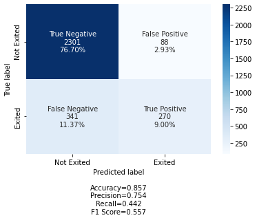

```python
cm1=confusion_matrix(y_test, y_pred)
labels = ['True Negative','False Positive','False Negative','True Positive']
categories = [ 'Not Exited','Exited']
make_confusion_matrix(cm1,
                      group_names=labels,
                      categories=categories,
                      cmap='Blues')
```

## Model evaluation criterion

### Model can make wrong predictions as:

- Predicting a customer is going to Exit and the customer does not exit
- Predicting a customer is not going to Exit and customer exits

### Which case is more important?

- Predicting customer is not going to Exit and customer exits. It will impact the bank monetarily and reduce the fund reserves and impact planning.

### How to reduce this loss i.e need to reduce False Negative?

- Bank would want `Recall` to be maximized, greater the Recall higher the chances of minimizing false Negative. Hence, the focus should be on increasing Recall or minimizing the false Negative or in other words identifying the True Positive(i.e. Class 1) so that the bank can identify the people who are going to exit.

# Deep neural network

### Model-1

- We will use a simple NN made of 5 fully-connected layers with ReLu activation. The NN takes a vector of length 11 as input. This represents the information related to each customer, ie each line with 11 columns from the dataset. For each customer, the final layer will output a probability distribution (sigmoid activation function) and classify either as not going to exit (0) or going to exit (1).
- a dropout step is included to prevent overfitting.

### Creating a model

Keras model object can be created with Sequential class

At the outset, the model is empty per se. It is completed by adding additional layers and compilation

```python
#initialize the model
model = Sequential()
```

### Adding layers [layers and activations]

Keras layers can be added to the model

Adding layers are like stacking lego blocks one by one

It should be noted that as this is a classification problem, sigmoid layer should be added

```python
# This adds the input layer (by specifying input dimension) AND the first hidden layer (units)
model.add(Dense(units=35,kernel_initializer = 'uniform', activation='relu',input_dim = 11))   # input of 11 columns as shown above

# hidden layer
model.add(Dense(units=45,kernel_initializer = 'uniform',activation='relu'))
#Adding Dropout to prevent overfitting
model.add(Dropout(0.5))
model.add(Dense(45,activation='relu'))
model.add(Dense(45,activation='relu'))

# Adding the output layer
# Notice that we do not need to specify input dim.
# we have an output of 1 node, which is the the desired dimensions of our output (Exited or not exited)
# We use the sigmoid because we want probability outcomes
model.add(Dense(1,activation='sigmoid'))                        # binary classification
```

[output not shown]

### Model compile [optimizers and loss functions]

Keras model should be "compiled" prior to training

Type of loss (function) used is binary_crossentropy and optimizer used is adam

```python
# Create optimizer with default learning rate
# Compile the model
model.compile(optimizer='adam',loss='binary_crossentropy',metrics=['accuracy'])
```

[output not shown]

#### Model summary

```python
model.summary()
```

```
Model: "sequential"
_________________________________________________________________
Layer (type)                 Output Shape              Param #
=================================================================
dense (Dense)                (None, 35)                420
_________________________________________________________________
dense_1 (Dense)              (None, 45)                1620
_________________________________________________________________
dropout (Dropout)            (None, 45)                0
_________________________________________________________________
dense_2 (Dense)              (None, 45)                2070
_________________________________________________________________
dense_3 (Dense)              (None, 45)                2070
_________________________________________________________________
dense_4 (Dense)              (None, 1)                 46
=================================================================
Total params: 6,226
Trainable params: 6,226
Non-trainable params: 0
_________________________________________________________________
```

## Training [Forward pass and Backpropagation]

Training the model

```python
#fitting the model
history=model.fit(X_train,y_train,batch_size=20,epochs=20,validation_split=0.2)
```

```
Train on 5600 samples, validate on 1400 samples
```

Plotting the train and test loss

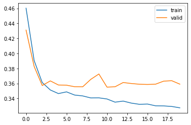

```python
# Capturing learning history per epoch
hist  = pd.DataFrame(history.history)
hist['epoch'] = history.epoch

# Plotting accuracy at different epochs
plt.plot(hist['loss'])
plt.plot(hist['val_loss'])
plt.legend(("train" , "valid") , loc =0)
```